# Análise estatística - Diamonds

sandropenha

05/09/2020

```r
knitr::opts_chunk$set(echo = TRUE, warning = FALSE)
```

#### **Sobre:**

Análise estatística do dataset **“diamonds”** disponibilizado pela biblioteca do **ggplot2**, uma das mais importantes bibliotecas para visualização de dados quando falamos em data science.

Dentre os objetivos deste projeto, estão a prática de técnicas de análise exploratória e modelagem estatística para obtenção de insights em relação aos dados.

O dataset possui variáveis categóricas e numéricas que explicam o preço de um diamante.

Serão aplicadas aqui as mais variadas técnicas de visualização e compreensão dos dados.

#### **Pré-visualização dos dados:**

```r
pacman::p_load(tidyverse,knitr,qcc,corrplot,lvplot,e1071,caret)
```

```r
df <- diamonds %>%
  select_all() %>%
  transmute(peso = carat,
            qualidade = cut,
            cor = color,
            claridade = clarity,
            comprimento = x,
            largura = y,
            profundidade = depth,
            tabela = table,
            preco = price);kable(head(df))
```

| peso | qualidade | cor | claridade | comprimento | largura | profundidade | tabela | preco |
| --- | --- | --- | --- | --- | --- | --- | --- | --- |
| 0.23 | Ideal | E | SI2 | 3.95 | 3.98 | 61.5 | 55 | 326 |
| 0.21 | Premium | E | SI1 | 3.89 | 3.84 | 59.8 | 61 | 326 |
| 0.23 | Good | E | VS1 | 4.05 | 4.07 | 56.9 | 65 | 327 |
| 0.29 | Premium | I | VS2 | 4.20 | 4.23 | 62.4 | 58 | 334 |
| 0.31 | Good | J | SI2 | 4.34 | 4.35 | 63.3 | 58 | 335 |
| 0.24 | Very Good | J | VVS2 | 3.94 | 3.96 | 62.8 | 57 | 336 |

#### **Número de diamantes por qualidade:**

**40%** dos diamantes presentes no dataset sao classificados como o tipo **“Ideal”**. Em valores absolutos, isso nos diz que há mais de 20.000 registros para esse tipo de diamantes presentes no dataset.

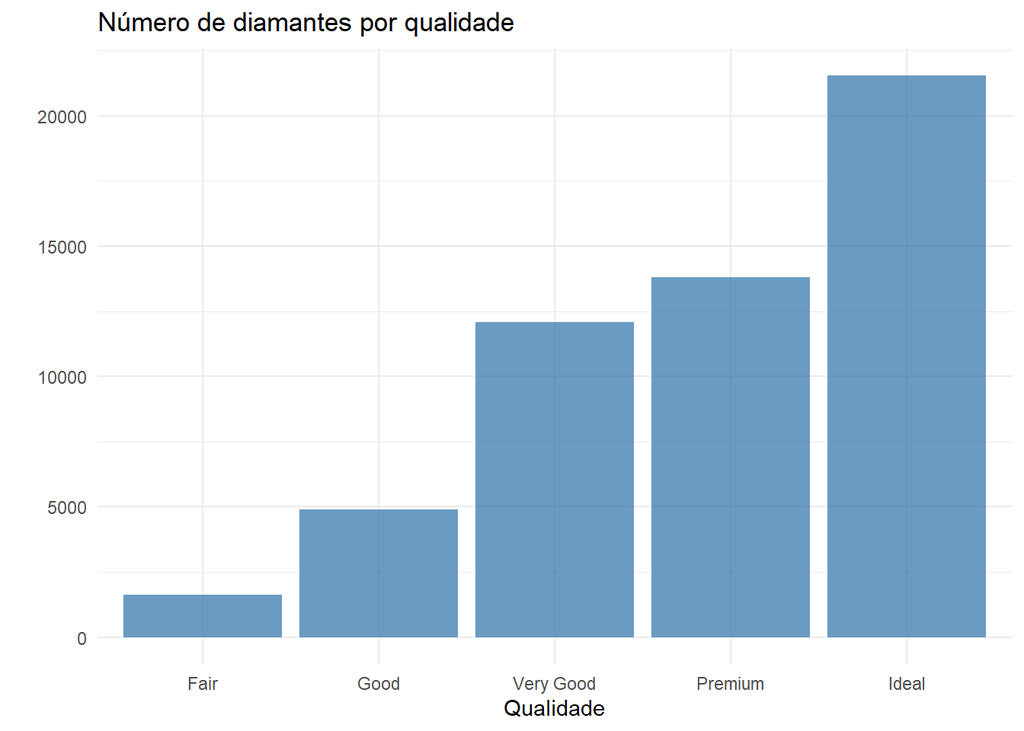

```r
p1 <- ggplot(df_fi,aes(x = qualidade))+
  geom_bar(aes(y = n),fill = "steelblue", alpha = 0.8, stat = "identity")+
  theme_minimal()+
  labs(title = "Número de diamantes por qualidade", x = "Qualidade",y="");p1
```

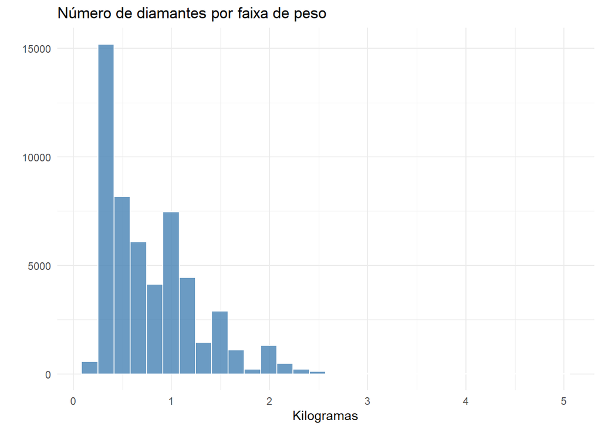

```r
p2 <- ggplot(df, aes(x = peso))+
  geom_histogram(bins = 30, fill = "steelblue", color = "white" ,alpha = 0.8)+
  theme_minimal()+
  labs(title = "Número de diamantes por faixa de peso", x = "Kilogramas", y="");p2
```

Grande parte dos diamantes possuem entre aproximadamente 0,25 e 1 kilogramas.

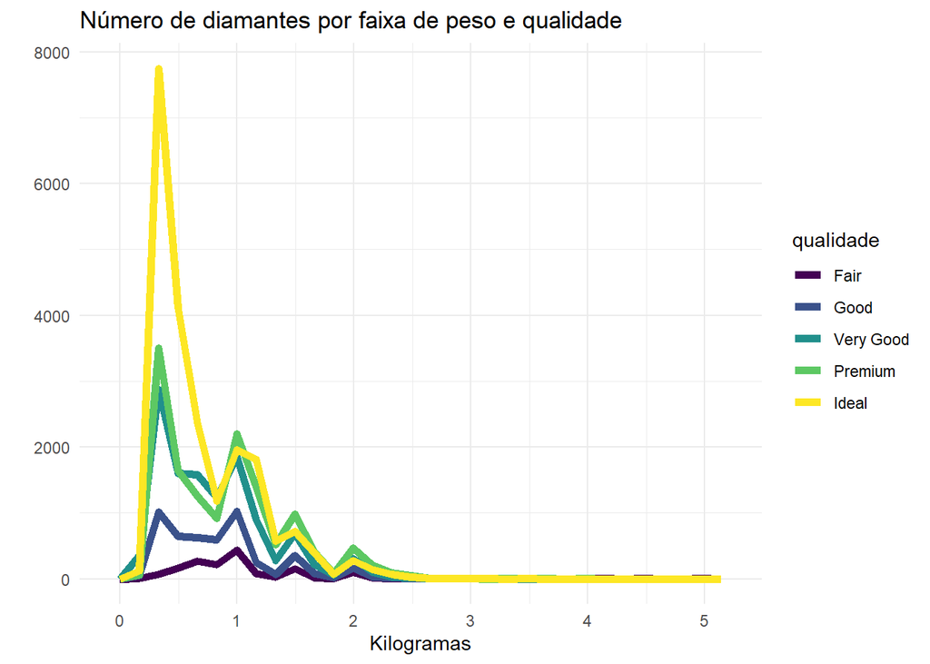

```r
options(warnings = -1)
p3 <- ggplot(df,aes(x = peso,color=qualidade))+
  geom_freqpoly(bins = 30,size = 2)+
  theme_minimal()+
  labs(title = "Número de diamantes por faixa de peso e qualidade", x = "Kilogramas",y="");p3
```

É possível ver aqui a relação do tipo de diamantes por qualidade e sua distribuição de contagem por Kilogramas.

Em sua grande maioria, diamantes do tipo **“Ideal”**, estão mais concentrados na faixa de aproximadamente 0,25 kilogramas.

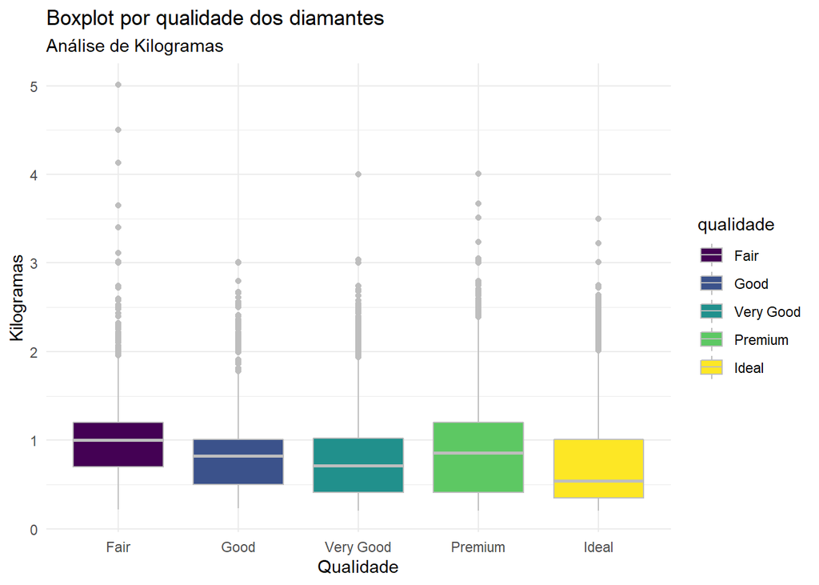

```r
p4 <- ggplot(df,aes(x = qualidade, y = peso, fill = qualidade))+
  geom_boxplot(color = "grey")+
  theme_minimal()+
  labs(title="Boxplot por qualidade dos diamantes", x = "Qualidade",y="Kilogramas",
       subtitle = "Análise de Kilogramas");p4
```

Há alguns insights interessantes que podemos tirar analisando o box-plot por peso e qualidade dos diamantes:

Diamantes do tipo **“Fair”** posssuem intervalo interquatilico **menor** que os demais tipos de diamantes, sendo o diamante do tipo **“Premium”**, o que possui **maior** intervalo interquatilico do conjunto de dados.

Essa medida é importante pois aqui conseguimos avaliar a variabilidade dos dados sem sofrer influência da presença de outliers (valores muito distantes da média).

Podemos medir a variabilidade também através da amplitude (valor máximo - valor minimo), a diferença é que aqui estamos considerando valores outliers.

Por essa visão, **“Fair”** é o tipo que mais apresenta variabilidade em sua distribuição de dados. É importante notar também a concentração de outliers na faixa acima de 4 Kilogramas para esse tipo de diamante, sendo o único a apresentar essa característica.

Também podemos notar que em todos os casos, temos a **média maior que a mediana**, pois o “bigode” possui inclinação para a parte superior, ou seja ambas as amostras podem ser ditas como assimétricas.

Tal observação é confirmada calculando o coeficiente de Assimetria (skewness).

#### **Considerações para o cálculo o coeficiente de Assimetria:**

Se menor que **-1 ou maior que 1**, a distribuição é **altamente distorcida**.

Se entre **-1 e -0,5 ou entre 0,5 e 1**, a distribuição é **enviesada moderadamente**.

Se entre **-0,5 e 0,5**, a distribuição é **aproximadamente simétrica**.

```r
premium <- df %>% filter(qualidade == "Premium")
ideal <- df %>% filter(qualidade == "Ideal")
verygood <- df %>% filter(qualidade == "Very Good")
good <- df %>% filter(qualidade == "Good")
fair <- df %>% filter(qualidade == "Fair")
```

**Coeficiente de Assimetria, avaliação de kilogramas dos diamantes:**

- **Premium:** 0.8615343
- **Ideal:** 1.339344
- **Very Good:** 0.9936572
- **Good:** 1.028119
- **Fair:** 1.683545

Pode-se concluir que as amostras são de fato assimétricas, pois para possuir simetria os coeficientes deveriam ficar entre **-0,5** e **0,5**, isso significa dizer que, temos um indicio comum de que as amostras não tratam-se de distribuições normais.

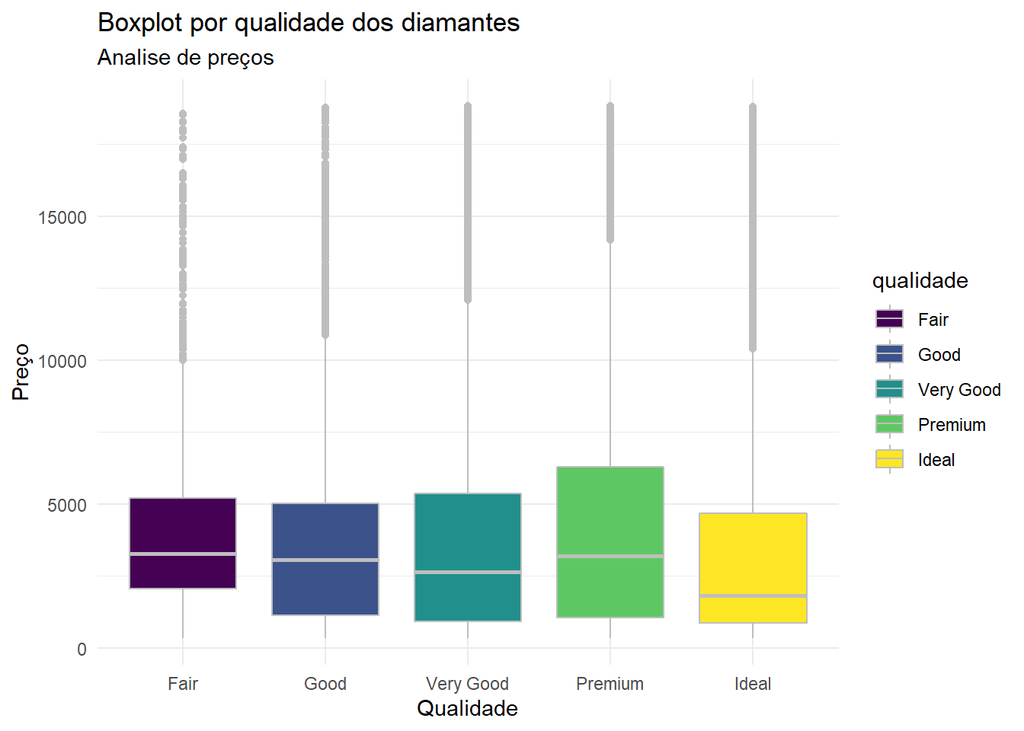

```r
p5 <- ggplot(df,aes(x = qualidade, y = preco, fill = qualidade))+
  geom_boxplot(color = "grey")+
  theme_minimal()+
  labs(title="Boxplot por qualidade dos diamantes", subtitles= "Analise de preços", x = "Qualidade",y="Preço");p5
```

Um insight interessante que podemos tirar dessa análise é que, diamantes do tipo **“Ideal”**, que é a melhor qualidade de diamantes, tem uma mediana de preço menor que os demais tipos de diamantes. Ou seja, a primeira vista, diamantes de qualidade inferior custam mais caro.

Para essas distribuições, também temos dados assimétricos.

Quando falamos em intervalo interquatilico, ou seja, a variabilidade dos dados desconsiderando os valores outliers, diamantes do tipo ‘Fair’, possuem menor variabilidade.

**Realizando teste de hipótese: Diamantes de qualidade inferior são realmente mais caros?**

Através do teste-T de student será verificada a hipótese de se de fato diamantes do tipo “**Fair**” custam mais caro que diamantes de qualidade superior:

Uma das premissas para a aplicação desse teste é a existência de uma distribuição normal dos dados. Contudo, existem 3 tipos de teste T:

- Teste T de amostras independentes
- Teste T de amostras relacionadas (pareados)
- Teste T de amostras normalmente distribuídas.

Para verificar se as amostras são normalmente distribuídas, realizaremos o shapiro Test antes nas seguintes condições:

- **h0:** Dados normalmente distribuíos
- **h1:** Dados não normalmente distribuídos
- se p-value **maior que 0.05 não rejeitamos** a hipotese nula e podemos assumir a normalidade dos dados.
- se p-value for **menor que 0.5, rejeitamos** a hipotese nula e não podemos assumir a normalidade dos dados.

```r
df_fair <- df %>% filter(qualidade == "Fair") %>% sample_frac(0.5)
df_ideal <- df %>% filter(qualidade == "Ideal") %>% sample_frac(0.2)
```

```
##
##  Shapiro-Wilk normality test
##
## data:  df_fair$preco
## W = 0.79648, p-value < 2.2e-16
```

```
##
##  Shapiro-Wilk normality test
##
## data:  df_ideal$preco
## W = 0.74741, p-value < 2.2e-16
```

Como o p-value de ambas as amostras estão abaixo de 0.5 rejeitamos a hipótese nula e **NÃO** podemos assumir a normalidade dos dados.

#### **Verificando se as amostras são independentes:**

```r
df_fair2 <- df_fair %>% select(preco) %>% sample_n(800);colnames(df_fair2) <- c("fair")
df_ideal2 <- df_ideal %>% select(preco) %>% sample_n(800);colnames(df_ideal2) <- c("ideal")
df_corr <- cbind(df_fair2,df_ideal2)
```

**Coeficiente de correlação de pearson:**

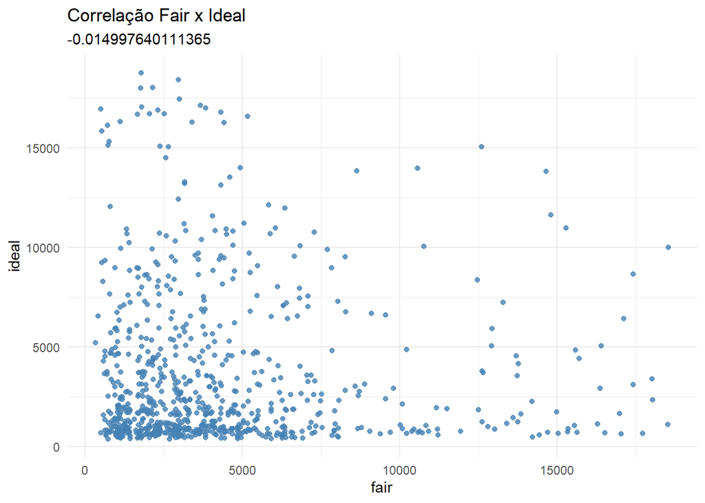

```r
ggplot(df_corr,aes(x=fair,y=ideal))+
  geom_point(color = "steelblue", alpha = 0.8)+
  labs(title = "Correlação Fair x Ideal",
       subtitle = cor(df_corr$fair,df_corr$ideal))+
  theme_minimal()
```

Visualizando tanto o coeficiente de correlação quanto o gráfico de dispersão, podemos concluir que de fato **não há correlação** alguma entre nossas amostras e então, podemos seguir com o teste de hipótese.

Vamos realizar um teste de hipótese bicaudal, ou seja, testaremos a hipótese de que o preço dos diamantes do tipo **“Fair”** e dos diamantes do tipo **“Ideal”** não apresentam diferenças significativas.

```
##
##  Welch Two Sample t-test
##
## data:  df_corr$fair and df_corr$ideal
## t = 3.8311, df = 1587.1, p-value = 0.0001325
## alternative hypothesis: true difference in means is not equal to 0
## 95 percent confidence interval:
##   343.4308 1064.0192
## sample estimates:
## mean of x mean of y
##  4213.376  3509.651
```

De acordo com o teste-t realizado, rejeitamos a hipotese nula, pois o valor p é muito baixo.

há diferenças significativas entre os preços dos dois tipos de diamantes e a análise de média nos diz que de fato, diamantes do tipo **“Fair”** são **mais caros** que os do tipo **“Ideal”**.

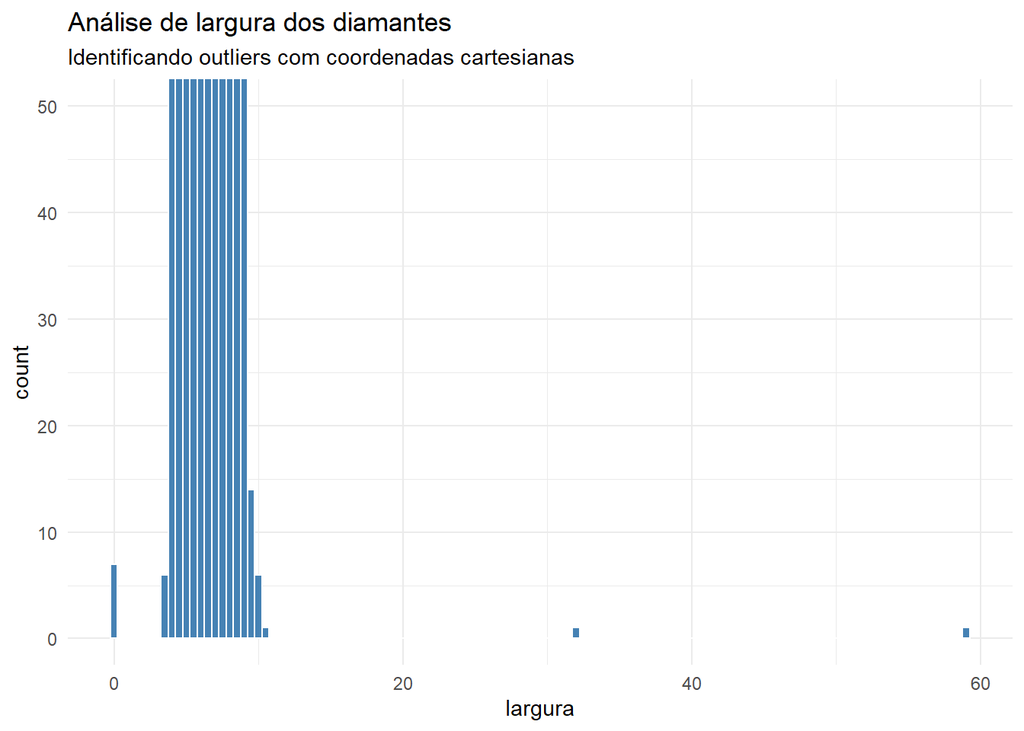

```r
p6 <- ggplot(df)+
  geom_histogram(aes(x = largura), binwidth = 0.5, fill = "steelblue", color = "white")+
  coord_cartesian(ylim = c(0,50))+
  ggtitle("Análise de largura dos diamantes",subtitle= "Identificando outliers com coordenadas cartesianas")+
  theme_minimal();p6
```

Há valores outliers na faixa intermediária de 30 e na faixa superior de 50 e também há valores na faixa de 0.

#### **Analisando os outliers mais a fundo**

Vamos aplicar um filtro em nossos dados afim de identificar as incosistências segundo os outliers encontrados no plot anterior.

Neste filtro, listaremos apenas os valores desde que largura = 0 e largura > 20.

```r
df_out <- df %>%
  filter(largura == 0 | largura > 20) %>%
  arrange(largura);kable(df_out)
```

| peso | qualidade | cor | claridade | comprimento | largura | profundidade | tabela | preco |
| --- | --- | --- | --- | --- | --- | --- | --- | --- |
| 1.00 | Very Good | H | VS2 | 0.00 | 0.0 | 63.3 | 53 | 5139 |
| 1.14 | Fair | G | VS1 | 0.00 | 0.0 | 57.5 | 67 | 6381 |
| 1.56 | Ideal | G | VS2 | 0.00 | 0.0 | 62.2 | 54 | 12800 |
| 1.20 | Premium | D | VVS1 | 0.00 | 0.0 | 62.1 | 59 | 15686 |
| 2.25 | Premium | H | SI2 | 0.00 | 0.0 | 62.8 | 59 | 18034 |
| 0.71 | Good | F | SI2 | 0.00 | 0.0 | 64.1 | 60 | 2130 |
| 0.71 | Good | F | SI2 | 0.00 | 0.0 | 64.1 | 60 | 2130 |
| 0.51 | Ideal | E | VS1 | 5.15 | 31.8 | 61.8 | 55 | 2075 |
| 2.00 | Premium | H | SI2 | 8.09 | 58.9 | 58.9 | 57 | 12210 |

```r
df2 <- df %>%
  mutate(largura = ifelse(largura < 3 | largura > 20, NA, largura))
kable(head(df2));kable(tail(df2))
```

| peso | qualidade | cor | claridade | comprimento | largura | profundidade | tabela | preco |
| --- | --- | --- | --- | --- | --- | --- | --- | --- |
| 0.23 | Ideal | E | SI2 | 3.95 | 3.98 | 61.5 | 55 | 326 |
| 0.21 | Premium | E | SI1 | 3.89 | 3.84 | 59.8 | 61 | 326 |
| 0.23 | Good | E | VS1 | 4.05 | 4.07 | 56.9 | 65 | 327 |
| 0.29 | Premium | I | VS2 | 4.20 | 4.23 | 62.4 | 58 | 334 |
| 0.31 | Good | J | SI2 | 4.34 | 4.35 | 63.3 | 58 | 335 |
| 0.24 | Very Good | J | VVS2 | 3.94 | 3.96 | 62.8 | 57 | 336 |

| peso | qualidade | cor | claridade | comprimento | largura | profundidade | tabela | preco |
| --- | --- | --- | --- | --- | --- | --- | --- | --- |
| 0.72 | Premium | D | SI1 | 5.69 | 5.73 | 62.7 | 59 | 2757 |
| 0.72 | Ideal | D | SI1 | 5.75 | 5.76 | 60.8 | 57 | 2757 |
| 0.72 | Good | D | SI1 | 5.69 | 5.75 | 63.1 | 55 | 2757 |
| 0.70 | Very Good | D | SI1 | 5.66 | 5.68 | 62.8 | 60 | 2757 |
| 0.86 | Premium | H | SI2 | 6.15 | 6.12 | 61.0 | 58 | 2757 |
| 0.75 | Ideal | D | SI2 | 5.83 | 5.87 | 62.2 | 55 | 2757 |

#### **Verificando valores outliers com correlação comprimento x largura:**

Uma outra forma de identificar valores outliers é correlacionar uma variável independente a uma variável dependente.

Isso também é muito útil para entendermos como se relacionam as variáveis do dataset. no caso, vamos correlacionar o comprimento com a largura, pois levando-se em consideração de que estamos falando de diamantes, o normal é que a medida que seu comprimento aumente, sua largura também deve aumentar.

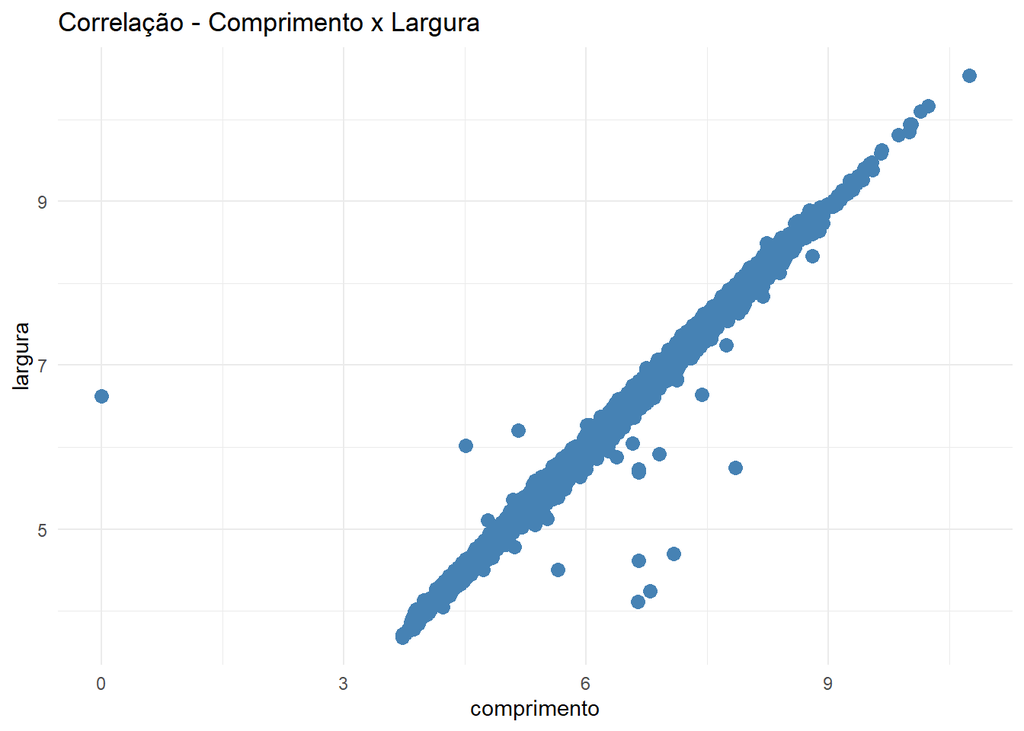

```r
p7 <- ggplot(df2, aes(x = comprimento, y = largura))+
  geom_point(color = "steelblue", size = 3)+
  theme_minimal()+
  ggtitle("Correlação - Comprimento x Largura");p7
```

O Gráfico de correlação nos mostra que esse padrão é verdadeiro.

Contudo, é possível identifcar um valor outlier na faixa de 0cm de comprimento.

Vamos aplicar a mesma técnica realizada anteriormente e filtrar esses valores a fim de, encontrarmos as inconsistências nos dados.

```r
df_com_out <- df2 %>%
  filter(comprimento <3);kable(df_com_out)
```

| peso | qualidade | cor | claridade | comprimento | largura | profundidade | tabela | preco |
| --- | --- | --- | --- | --- | --- | --- | --- | --- |
| 1.07 | Ideal | F | SI2 | 0 | 6.62 | 61.6 | 56 | 4954 |
| 1.00 | Very Good | H | VS2 | 0 | NA | 63.3 | 53 | 5139 |
| 1.14 | Fair | G | VS1 | 0 | NA | 57.5 | 67 | 6381 |
| 1.56 | Ideal | G | VS2 | 0 | NA | 62.2 | 54 | 12800 |
| 1.20 | Premium | D | VVS1 | 0 | NA | 62.1 | 59 | 15686 |
| 2.25 | Premium | H | SI2 | 0 | NA | 62.8 | 59 | 18034 |
| 0.71 | Good | F | SI2 | 0 | NA | 64.1 | 60 | 2130 |
| 0.71 | Good | F | SI2 | 0 | NA | 64.1 | 60 | 2130 |

Nosso grafico havia desconsiderado outros valores com comprimento = 0 pois os dados de largura estavam como **NA** (valores faltantes). Vamos desconsiderar os inputs errados do dataset.

```r
df3 <- df2 %>%
  mutate(comprimento = ifelse(comprimento < 3, NA, comprimento));kable(head(df3));kable(tail(df3))
```

| peso | qualidade | cor | claridade | comprimento | largura | profundidade | tabela | preco |
| --- | --- | --- | --- | --- | --- | --- | --- | --- |
| 0.23 | Ideal | E | SI2 | 3.95 | 3.98 | 61.5 | 55 | 326 |
| 0.21 | Premium | E | SI1 | 3.89 | 3.84 | 59.8 | 61 | 326 |
| 0.23 | Good | E | VS1 | 4.05 | 4.07 | 56.9 | 65 | 327 |
| 0.29 | Premium | I | VS2 | 4.20 | 4.23 | 62.4 | 58 | 334 |
| 0.31 | Good | J | SI2 | 4.34 | 4.35 | 63.3 | 58 | 335 |
| 0.24 | Very Good | J | VVS2 | 3.94 | 3.96 | 62.8 | 57 | 336 |

| peso | qualidade | cor | claridade | comprimento | largura | profundidade | tabela | preco |
| --- | --- | --- | --- | --- | --- | --- | --- | --- |
| 0.72 | Premium | D | SI1 | 5.69 | 5.73 | 62.7 | 59 | 2757 |
| 0.72 | Ideal | D | SI1 | 5.75 | 5.76 | 60.8 | 57 | 2757 |
| 0.72 | Good | D | SI1 | 5.69 | 5.75 | 63.1 | 55 | 2757 |
| 0.70 | Very Good | D | SI1 | 5.66 | 5.68 | 62.8 | 60 | 2757 |
| 0.86 | Premium | H | SI2 | 6.15 | 6.12 | 61.0 | 58 | 2757 |
| 0.75 | Ideal | D | SI2 | 5.83 | 5.87 | 62.2 | 55 | 2757 |

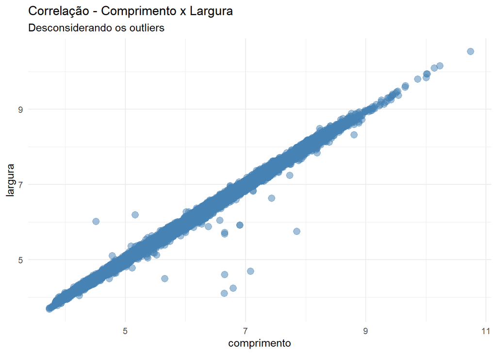

```r
p8 <- ggplot(df3, aes(x = comprimento, y = largura))+
  geom_point(color = "steelblue", size = 3, alpha = 0.5)+
  theme_minimal()+
  ggtitle("Correlação - Comprimento x Largura", subtitle = "Desconsiderando os outliers");p8
```

**Conclusão:**

Comprimento x largura possuem **forte correlação positiva**.

Podemos avaliar ainda, quais variáveis são mais determinantes para a precificação dos diamantes.

Faremos isso utilizando uma matriz de correlação com o corrplot

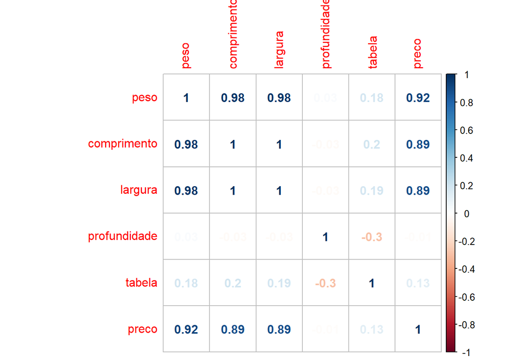

```r
df4 <- df3 %>%
  drop_na()
num_vars <- sapply(df4, is.numeric)
cor <- cor(df4[num_vars])
corrplot(cor,method = "number")
```

Aqui, podemos ver que, o **peso**, **comprimento** e **largura** são as variáveis mais determinantes para o preço de um diamante, enquanto as demais variáveis possuem pouca significância.

Também podemos analisar o que determina a qualidade de um diamante quando este é Ideal, Premium, Good e etc.

Isso também nos auxiliará a entender o motivo pelo qual diamantes do tipo “Fair” (pior qualidade) tem mediana de preços mais elevados que diamantes do tipo “Ideal” (melhor qualidade).

Para isso, vamos padronizar nossos dados, e transformar a variavel “qualidade” em numérica e em seguida fazer o estudo de correlação.

#### **Definição das variáveis categóricas:**

**Qualidade:**

- 1: Fair
- 2: Good:
- 3: Very Good
- 4: Premium
- 5: Ideal

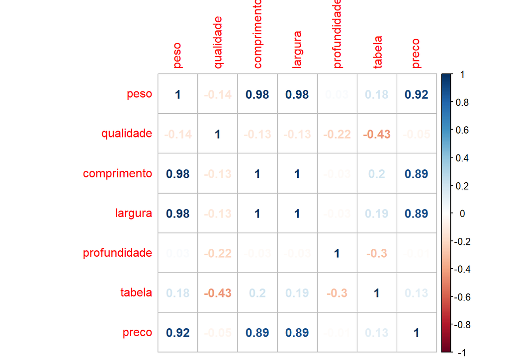

```r
df_ <- df4 %>%
  mutate(qualidade = ifelse(qualidade == "Fair", 1,
                            ifelse(qualidade == "Good",2,
                                   ifelse(qualidade == "Very Good",3,
                                          ifelse(qualidade == "Premium",4,5)))))

num_vars <- sapply(df_,is.numeric)
cor <- cor(df_[num_vars])
corrplot(cor,method = "number")
```

A variáve qualidade, **não** é peça determinante na composição do preço do diamante, mas sim seu comprimento, largura e principlamente seu peso.

Muito provalvelmente, diamantes de qualidade inferior costumam pesar mais, logo tem preço maior. Vamos verificar esse hipótese estudando o peso dos diamantes novamente:

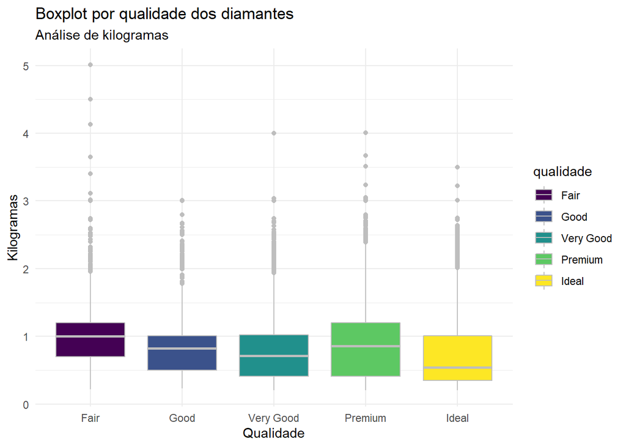

```r
p4 <- ggplot(df,aes(x = qualidade, y = peso, fill = qualidade))+
  geom_boxplot(color = "grey")+
  theme_minimal()+
  labs(title="Boxplot por qualidade dos diamantes",subtitle = "Análise de kilogramas", x = "Qualidade",y="Kilogramas");p4
```

Revisitando esse plot acerca dos kilogramas dos diamantes por qualidade, podemos atestar aqui que, diamantes de qualidade inferior (Fair) possuem **mais kilogramas** em comparação com diamantes de qualidade superior (Ideal).

Ou seja, diamantes “Fair” são mais caros pois possuem mais kilogramas, pois conforme vimos no plot de correlação, Peso é a variável que mais está correlacionada ao Preço.

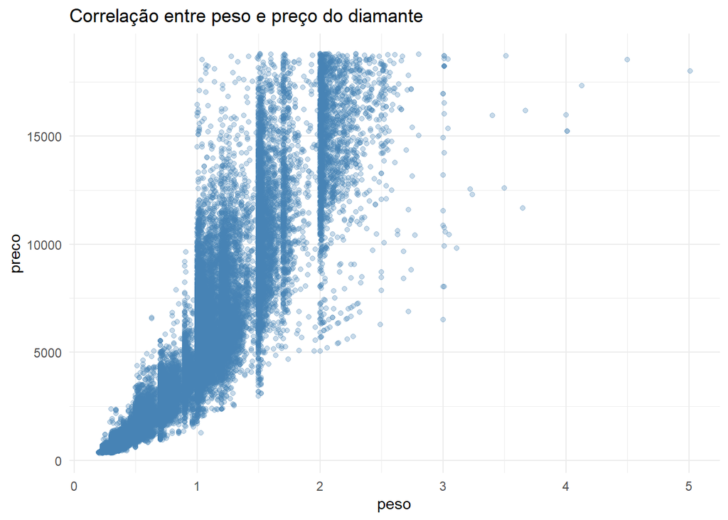

```r
plot <- ggplot(df_, aes(x = peso, y = preco))+
  geom_point(color = "steelblue", alpha = 0.3)+
  theme_minimal()+
  ggtitle("Correlação entre peso e preço do diamante");plot
```

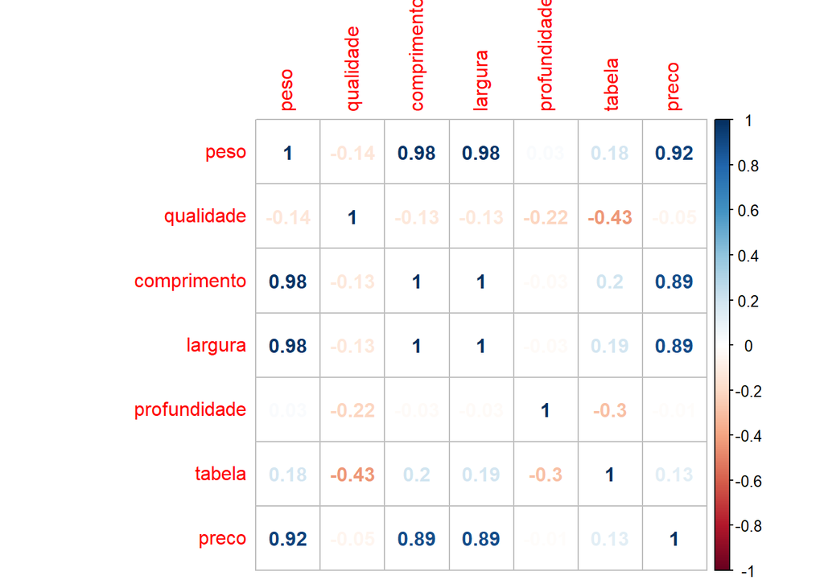

```r
corrplot(cor,method = "number")
```

É possível ver também que há correlação negativa moderada entre qualidade e tabela (largura do topo do diamante em relação ao ponto mais largo), ou seja, quanto menor a largura do topo em relação ao ponto mais largo do diamante, sua qualidade tende a aumentar.

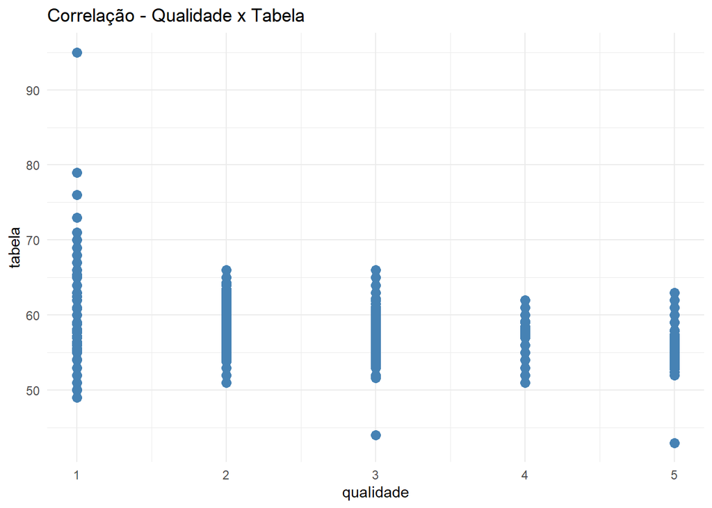

```r
p9 <- ggplot(df_,aes(x = qualidade,y=tabela))+
  geom_point(size = 3, color = "steelblue")+
  theme_minimal()+
  ggtitle("Correlação - Qualidade x Tabela");p9
```

#### **Plotando principais correlações:**

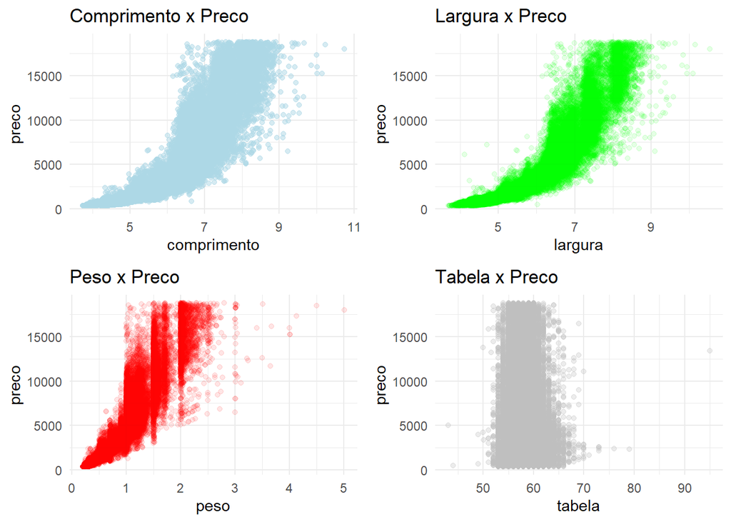

```r
p10 <- ggplot(df_,aes(x=comprimento,y=preco))+
  geom_point(color = "lightblue",alpha = 0.5)+
  theme_minimal()+
  ggtitle("Comprimento x Preco")

p11 <- ggplot(df_,aes(x=largura,y=preco))+
  geom_point(color = "green",alpha = 0.1)+
  theme_minimal()+
  ggtitle("Largura x Preco")

p12 <-  ggplot(df_,aes(x=peso,y=preco))+
  geom_point(color = "red",alpha = 0.1)+
  theme_minimal()+
  ggtitle("Peso x Preco")

p13 <-  ggplot(df_,aes(x=tabela,y=preco))+
  geom_point(color = "grey",alpha = 0.3)+
  theme_minimal()+
  ggtitle("Tabela x Preco")


gridExtra::grid.arrange(p10,p11,p12,p13,nrow = 2)
```

#### **Construção do modelo preditivo:**

Após realização da análise preditiva, realizaremos aqui a construção de um modelo de machine learning que possa prever com precisão o preço que será aplicado a venda dos diamantes.

Já vimos anteriormente na análise preditiva que, o principal fator que compõe o preço final de um diamante é o seu peso em kilogramas.

Vimos também, que a qualidade do diamante não é determinante ao seu valor final.

#### **Verificando variáveis multicolineares**

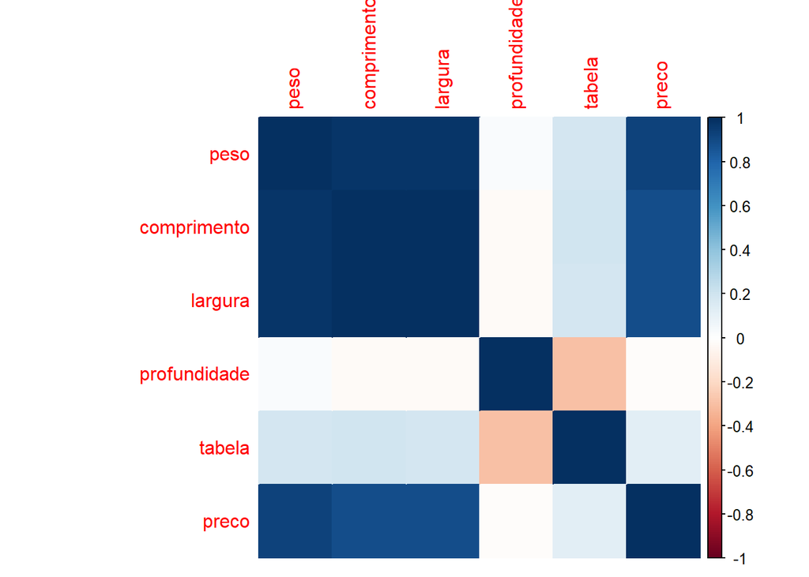

```r
num_vars <- sapply(df4,is.numeric)
corr <- cor(df4[,num_vars])
corrplot(corr,method = "color")
```

Comprimento e largura possuem multicolinearidade, teremos que dropar essas variáveis ou o modelo poderá ficar instável e tendencioso.

```r
modelo1 <- lm(preco~.,df);summary(modelo1)
```

```
##
## Call:
## lm(formula = preco ~ ., data = df)
##
## Residuals:
##      Min       1Q   Median       3Q      Max
## -21383.5   -592.4   -183.6    376.6  10694.6
##
## Coefficients:
##               Estimate Std. Error  t value Pr(>|t|)
## (Intercept)   5930.639    378.619   15.664  < 2e-16 ***
## peso         11256.480     48.627  231.487  < 2e-16 ***
## qualidade.L    584.635     22.478   26.009  < 2e-16 ***
## qualidade.Q   -301.849     17.994  -16.775  < 2e-16 ***
## qualidade.C    147.807     15.483    9.547  < 2e-16 ***
## qualidade^4    -21.376     12.371   -1.728  0.08400 .
## cor.L        -1952.115     17.342 -112.566  < 2e-16 ***
## cor.Q         -672.198     15.777  -42.607  < 2e-16 ***
## cor.C         -165.460     14.725  -11.237  < 2e-16 ***
## cor^4           38.264     13.527    2.829  0.00467 **
## cor^5          -95.825     12.776   -7.500 6.47e-14 ***
## cor^6          -48.449     11.614   -4.172 3.03e-05 ***
## claridade.L   4096.784     30.256  135.405  < 2e-16 ***
## claridade.Q  -1924.591     28.226  -68.185  < 2e-16 ***
## claridade.C    981.925     24.151   40.658  < 2e-16 ***
## claridade^4   -364.833     19.285  -18.918  < 2e-16 ***
## claridade^5    233.401     15.752   14.818  < 2e-16 ***
## claridade^6      6.984     13.715    0.509  0.61061
## claridade^7     90.752     12.103    7.498 6.57e-14 ***
## comprimento  -1035.051     27.603  -37.498  < 2e-16 ***
## largura          5.795     19.164    0.302  0.76235
## profundidade   -66.727      4.093  -16.302  < 2e-16 ***
## tabela         -26.440      2.912   -9.081  < 2e-16 ***
## ---
## Signif. codes:  0 '***' 0.001 '**' 0.01 '*' 0.05 '.' 0.1 ' ' 1
##
## Residual standard error: 1130 on 53917 degrees of freedom
## Multiple R-squared:  0.9198, Adjusted R-squared:  0.9198
## F-statistic: 2.81e+04 on 22 and 53917 DF,  p-value: < 2.2e-16
```

A primeira vista, nosso modelo ficou muito bom, possui variáveis significantes, R2 alto, p-value baixo. Entretanto ainda há variáveis que possuem multicolinearidade, além dos valores numéricos estarem em escalas diferentes. Vamos realizar esses ajustes e em seguida separar os dados entre dados de treino e teste para criação de um novo modelo preditivo mais assertivo.

#### **Normatização e drop de variáveis multicolineares**

```r
normatizados <- df4 %>% select(-preco) %>% mutate_if(is.numeric,scale);head(normatizados)
```

```
## # A tibble: 6 x 8
##   peso[,1] qualidade cor   claridade comprimento[,1] largura[,1]
##      <dbl> <ord>     <ord> <ord>               <dbl>       <dbl>
## 1    -1.20 Ideal     E     SI2                 -1.59       -1.58
## 2    -1.24 Premium   E     SI1                 -1.65       -1.70
## 3    -1.20 Good      E     VS1                 -1.50       -1.50
## 4    -1.07 Premium   I     VS2                 -1.37       -1.35
## 5    -1.03 Good      J     SI2                 -1.24       -1.24
## 6    -1.18 Very Good J     VVS2                -1.60       -1.60
## # ... with 2 more variables: profundidade[,1] <dbl>, tabela[,1] <dbl>
```

```r
target <- df4 %>% select(preco);head(target)
```

```
## # A tibble: 6 x 1
##   preco
##   <int>
## 1   326
## 2   326
## 3   327
## 4   334
## 5   335
## 6   336
```

```r
dados_normatizados <- cbind(normatizados,target);head(dados_normatizados)
```

```
##        peso qualidade cor claridade comprimento   largura profundidade
## 1 -1.198111     Ideal   E       SI2   -1.591558 -1.577862   -0.1740943
## 2 -1.240308   Premium   E       SI1   -1.645146 -1.703819   -1.3608406
## 3 -1.198111      Good   E       VS1   -1.502243 -1.496890   -3.3852900
## 4 -1.071519   Premium   I       VS2   -1.368272 -1.352940    0.4541831
## 5 -1.029322      Good   J       SI2   -1.243232 -1.244977    1.0824605
## 6 -1.177013 Very Good   J      VVS2   -1.600489 -1.595856    0.7334175
##       tabela preco
## 1 -1.0998190   326
## 2  1.5858507   326
## 3  3.3762971   327
## 4  0.2430158   334
## 5  0.2430158   335
## 6 -0.2045958   336
```

```r
df <- dados_normatizados %>% select(-comprimento,-largura)
```

```r
treino <- df %>% sample_frac(0.7)
teste <- df %>% sample_frac(0.3)
```

#### **Imprimindo variáveis mais importantes**

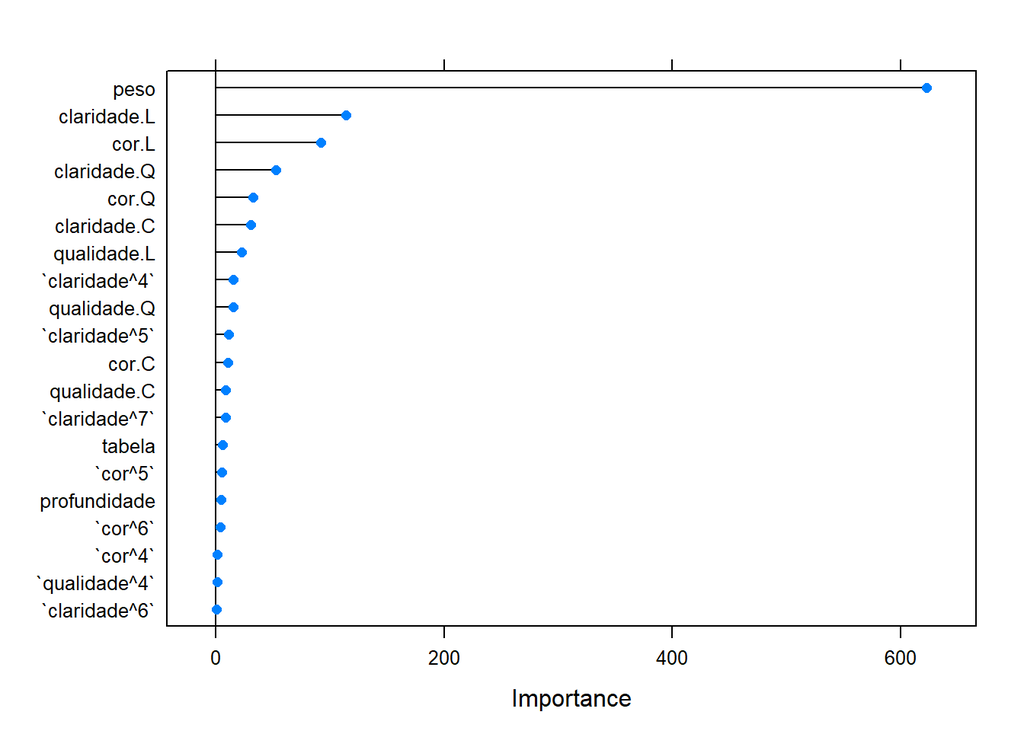

```r
control <- trainControl(method = "repeatedcv", number = 10, repeats = 2 )
model <- train(preco~., data = treino, method = "glm")
importance <- varImp(model,scale = FALSE)
plot(importance)
```

Vemos aqui que, de longe, a variável mais importante para a construção do modelo preditivo é a variável peso, podemos cogitar dropar algumas variáveis para que o modelo fique assim mais genérico e estável.

```r
modelo2 <- lm(preco~peso+claridade+cor,data=treino);summary(modelo2)
```

```
##
## Call:
## lm(formula = preco ~ peso + claridade + cor, data = treino)
##
## Residuals:
##      Min       1Q   Median       3Q      Max
## -12443.6   -674.9   -192.7    468.9  10315.1
##
## Coefficients:
##              Estimate Std. Error t value Pr(>|t|)
## (Intercept)  3566.892      9.579 372.371  < 2e-16 ***
## peso         4196.274      6.773 619.604  < 2e-16 ***
## claridade.L  4361.241     36.048 120.983  < 2e-16 ***
## claridade.Q -1900.660     33.989 -55.920  < 2e-16 ***
## claridade.C   968.688     29.206  33.167  < 2e-16 ***
## claridade^4  -400.360     23.369 -17.132  < 2e-16 ***
## claridade^5   248.839     19.183  12.972  < 2e-16 ***
## claridade^6    -5.500     16.813  -0.327    0.744
## claridade^7   129.811     14.817   8.761  < 2e-16 ***
## cor.L       -1930.007     21.123 -91.369  < 2e-16 ***
## cor.Q        -626.757     19.205 -32.634  < 2e-16 ***
## cor.C        -195.745     17.967 -10.895  < 2e-16 ***
## cor^4          19.417     16.554   1.173    0.241
## cor^5         -83.517     15.612  -5.349 8.87e-08 ***
## cor^6         -65.758     14.207  -4.629 3.69e-06 ***
## ---
## Signif. codes:  0 '***' 0.001 '**' 0.01 '*' 0.05 '.' 0.1 ' ' 1
##
## Residual standard error: 1157 on 37736 degrees of freedom
## Multiple R-squared:  0.9159, Adjusted R-squared:  0.9159
## F-statistic: 2.937e+04 on 14 and 37736 DF,  p-value: < 2.2e-16
```

```r
modelo3 <- lm(preco~peso,treino);summary(modelo3)
```

```
##
## Call:
## lm(formula = preco ~ peso, data = treino)
##
## Residuals:
##      Min       1Q   Median       3Q      Max
## -14494.2   -801.7    -15.9    538.8  12736.5
##
## Coefficients:
##             Estimate Std. Error t value Pr(>|t|)
## (Intercept) 3927.639      7.902   497.0   <2e-16 ***
## peso        3675.803      7.890   465.9   <2e-16 ***
## ---
## Signif. codes:  0 '***' 0.001 '**' 0.01 '*' 0.05 '.' 0.1 ' ' 1
##
## Residual standard error: 1535 on 37749 degrees of freedom
## Multiple R-squared:  0.8518, Adjusted R-squared:  0.8518
## F-statistic: 2.17e+05 on 1 and 37749 DF,  p-value: < 2.2e-16
```

Dropar as variáveis praticamente não afetou o desempenho do R2 do modelo, além de deixa-lo mais estável e menos enviesado. Em outras palavras, o modelo 2 é o que apresenta melhor desempenho. mas vamos confirmar esse hipotese analisando mais a fundo os três modelos criados.

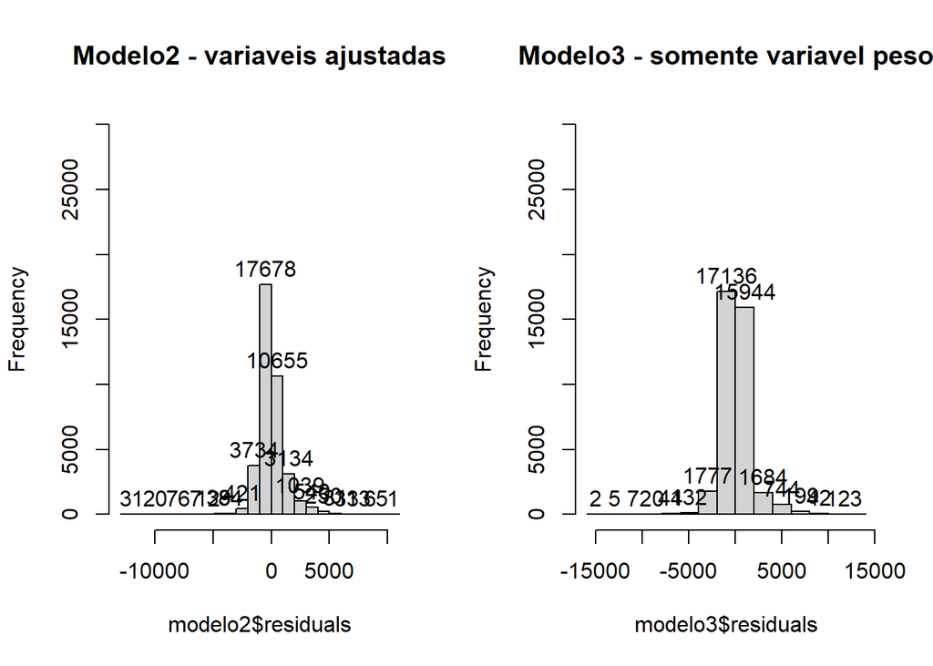

```r
par(mfrow=c(1,2))
hist(modelo2$residuals, labels = TRUE, ylim = c(0,30000), main = "Modelo2 - variaveis ajustadas")
hist(modelo3$residuals, labels = TRUE, ylim = c(0,30000), main = "Modelo3 - somente variavel peso")
```

Nesse plot, vemos que o desempenho residual do modelo 2 foi melhor que a do modelo 3, pois a concentração dos residuals está mais localizado ao centro (zero)

**MOdelo 2**

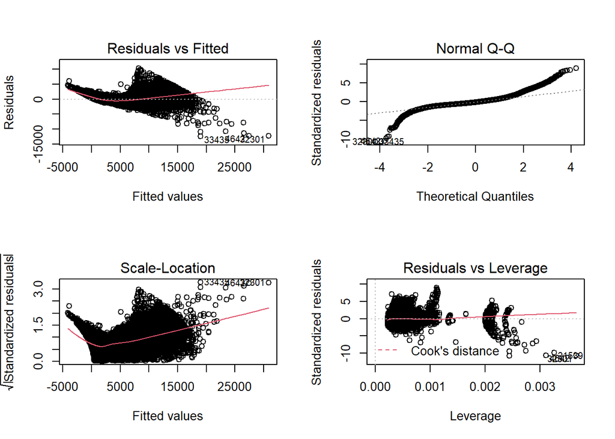

```r
par(mfrow = c(2,2))
plot(modelo2)
```

**Modelo 3**

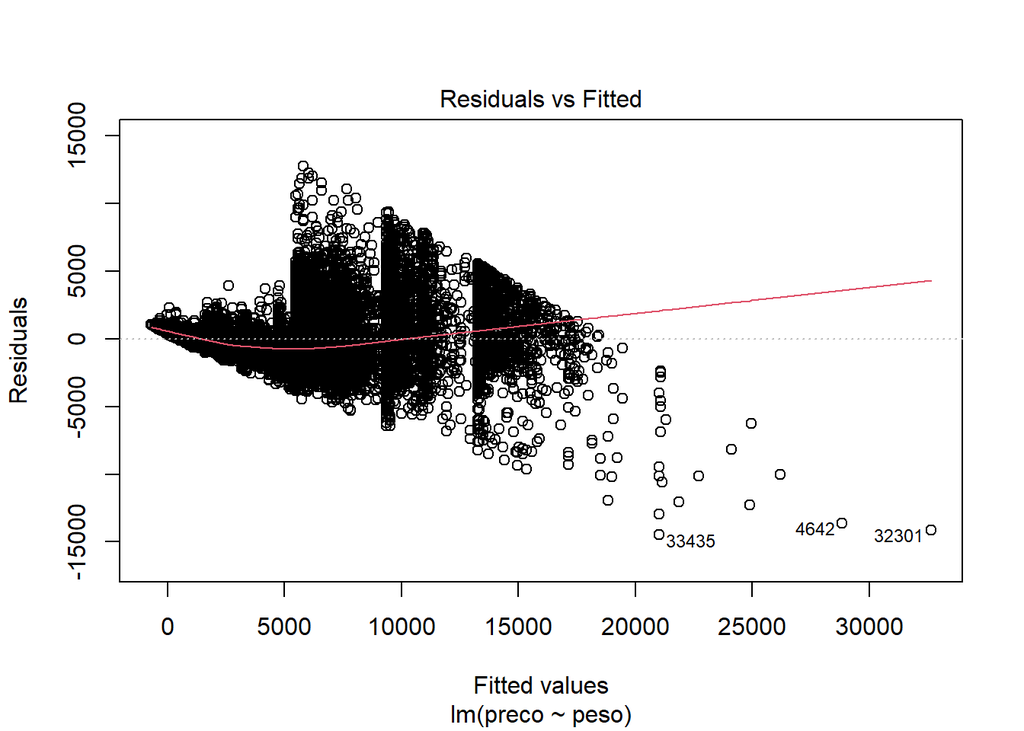

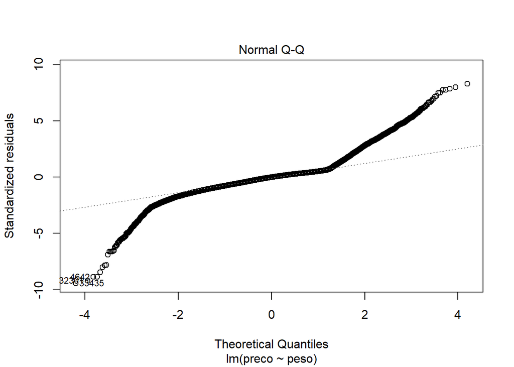

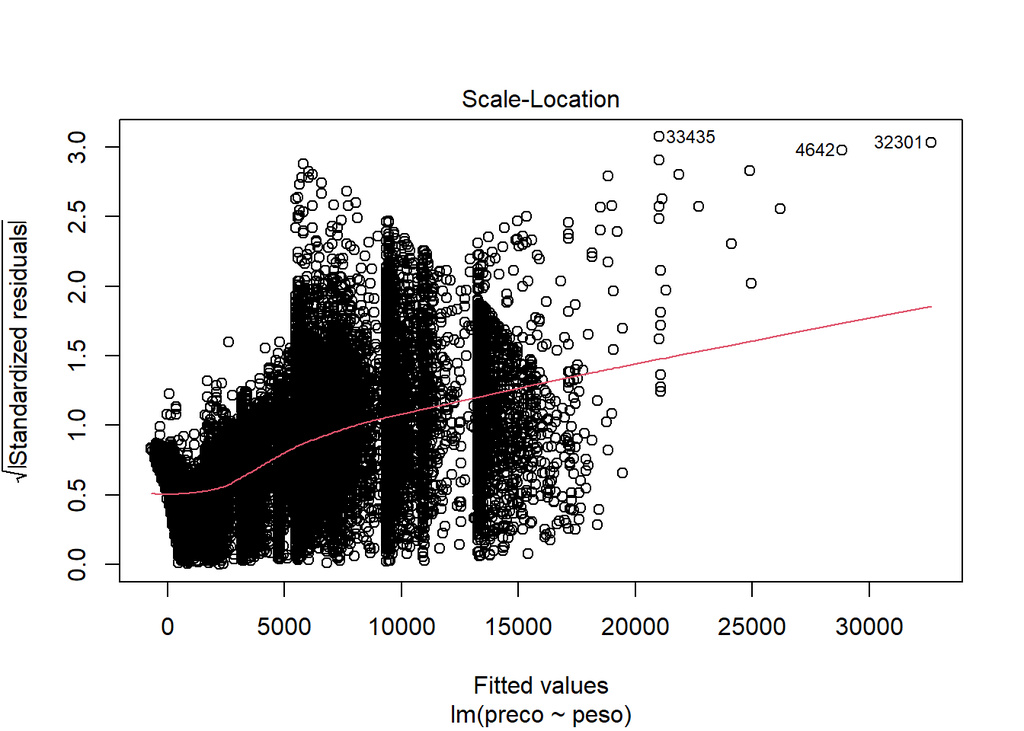

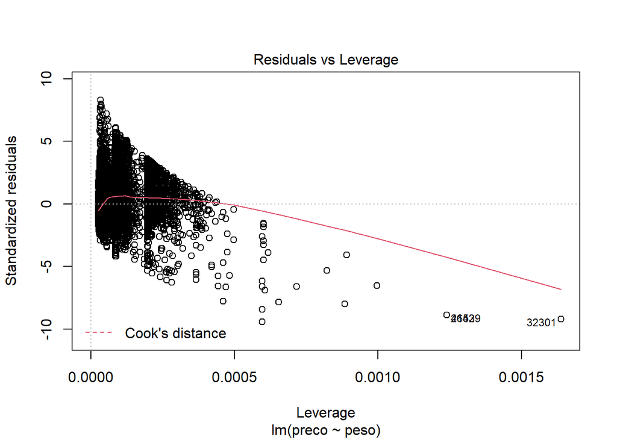

```r
plot(modelo3)
```

Também é possível aqui que o modelo 2 também apresenta menos fuga dos residuals em torno do zero

#### **Ajustando dados de teste para o formato dos de treino:**

```r
teste <- teste %>% select(preco,peso,claridade,cor)
```

```r
previsao <- predict(modelo3,teste)
mean(previsao)
```

```
## [1] 3941.403
```

```r
mean(teste$preco)
```

```
## [1] 3924.531
```

Comparando também a média dos valores previstos com os valores do dataset de testes vemos que ficaram muito próximas. O que é muito bom.

```r
previsao <- as.data.frame(previsao)
df_previsto <- cbind(teste,previsao)
head(df_previsto)
```

```
##   preco       peso claridade cor  previsao
## 1 10055  2.3042593       SI2   G 12397.642
## 2  5203  2.6629358        I1   J 13716.066
## 3  1929 -0.2064762       SI2   E  3168.673
## 4   505 -0.9238292       SI2   G   531.825
## 5  4269  0.2154962       VS2   G  4719.760
## 6  2210 -0.5440540        IF   H  1927.803
```

```r
df_previsto <- df_previsto %>%
  select(peso,claridade,cor,preco,previsao) %>%
  mutate(previsao = round(previsao),
         previsaoxreal = previsao-preco)
```